# Synthetische Gehirne, 3D-CNNs und LRP

### Interpretation

- **Die räumliche Struktur ist deutlich anders als bei Modell 1.** Statt der diffusen Kleeblatt-Wolke zeigen die Karten nun einen **Ring entlang der Kugelkontur** mit hellen Kernen im Inneren und kräftigen Punkten dort, wo Tunnel die Oberfläche durchbrechen. Die Relevanz sitzt also an *Kanten*, was für die Aufgabe die richtige Struktur ist.
- **Die Redundanz ist aber nicht verschwunden.** Auch hier gleichen sich die 32 Karten im Muster stark und unterscheiden sich vor allem im **Vorzeichen** — einige Neuronen liefern rote Ringe, andere fast pixelgleiche blaue Ringe. Zwei Neuronen, deren Heatmaps sich nur im Vorzeichen unterscheiden, sind informationstheoretisch dasselbe Merkmal.
- **Warum bleibt die Redundanz?** Vermutlich schlicht wegen der zwei Epochen: Die Gewichte sind noch nahe der Zufallsinitialisierung, und die Gradienten für alle 32 Neuronen zeigen anfangs in ähnliche Richtungen (alle bekommen ihr Signal über denselben skalaren Fehler der Ausgabeschicht). Ausdifferenzierung braucht Training. Ein Gegentest wäre, dieselbe Analyse nach 500 Epochen zu wiederholen und die Vielfalt der Karten zu vergleichen.
- **Auch hier keine übersprungene Karte:** Das `if np.sum(explanations) == 0` greift nicht, es werden alle 32 Karten gezeichnet. Auf der *linearen* `Dense(32)`-Schicht gibt es also keine toten Einheiten. Das ist ein wichtiger Kontrast zur nächsten Zelle, die die *ReLU*-Ausgabe derselben Schicht betrachtet — und dort sehr wohl tote Neuronen findet.

```
1/1 ━━━━━━━━━━━━━━━━━━━━ 0s 2s/step
```

```
1/1 ━━━━━━━━━━━━━━━━━━━━ 2s 2s/step
```

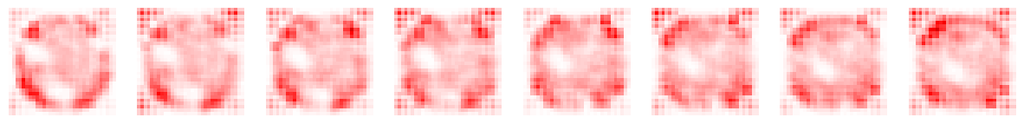

```
1/1 ━━━━━━━━━━━━━━━━━━━━ 0s 2s/step
```

```
1/1 ━━━━━━━━━━━━━━━━━━━━ 2s 2s/step
```

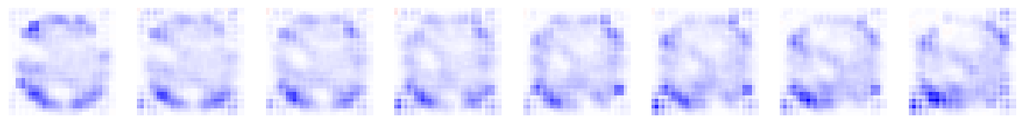

```
1/1 ━━━━━━━━━━━━━━━━━━━━ 0s 2s/step
```

```
1/1 ━━━━━━━━━━━━━━━━━━━━ 2s 2s/step
```

[figure not shown]

```
1/1 ━━━━━━━━━━━━━━━━━━━━ 0s 2s/step
```

```
1/1 ━━━━━━━━━━━━━━━━━━━━ 2s 2s/step
```

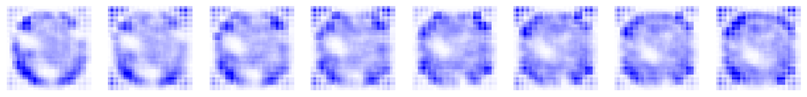

```
1/1 ━━━━━━━━━━━━━━━━━━━━ 0s 2s/step
```

```
1/1 ━━━━━━━━━━━━━━━━━━━━ 2s 2s/step
```

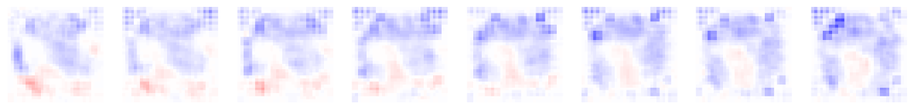

```
1/1 ━━━━━━━━━━━━━━━━━━━━ 0s 2s/step
```

```
1/1 ━━━━━━━━━━━━━━━━━━━━ 2s 2s/step
```

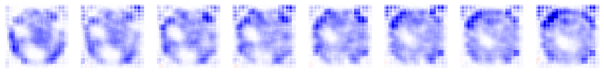

```
1/1 ━━━━━━━━━━━━━━━━━━━━ 0s 2s/step
```

```
1/1 ━━━━━━━━━━━━━━━━━━━━ 2s 2s/step
```

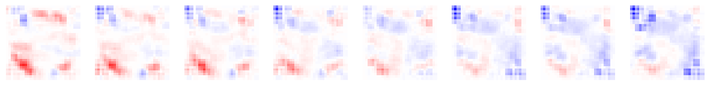

```
1/1 ━━━━━━━━━━━━━━━━━━━━ 0s 2s/step
```

```
1/1 ━━━━━━━━━━━━━━━━━━━━ 2s 2s/step
```

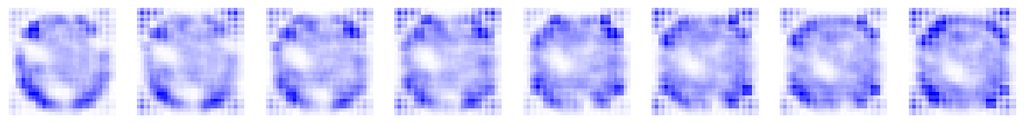

```
1/1 ━━━━━━━━━━━━━━━━━━━━ 0s 2s/step
```

```
1/1 ━━━━━━━━━━━━━━━━━━━━ 2s 2s/step
```

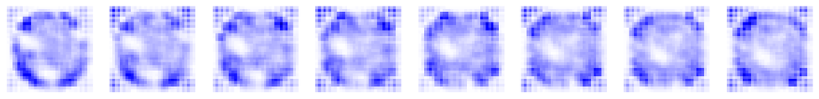

```
1/1 ━━━━━━━━━━━━━━━━━━━━ 0s 2s/step
```

```
1/1 ━━━━━━━━━━━━━━━━━━━━ 2s 2s/step
```

[figure not shown]

```
1/1 ━━━━━━━━━━━━━━━━━━━━ 0s 2s/step
```

```
1/1 ━━━━━━━━━━━━━━━━━━━━ 2s 2s/step
```

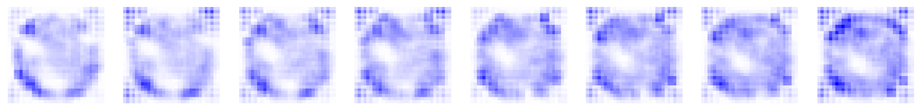

```
1/1 ━━━━━━━━━━━━━━━━━━━━ 0s 2s/step
```

```
1/1 ━━━━━━━━━━━━━━━━━━━━ 2s 2s/step
```

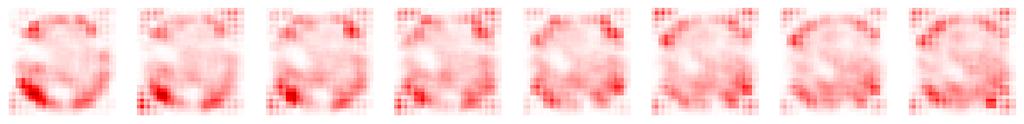

```
1/1 ━━━━━━━━━━━━━━━━━━━━ 0s 2s/step
```

```
1/1 ━━━━━━━━━━━━━━━━━━━━ 2s 2s/step
```

[20 more figures not shown]

```python
tmp = Model(model.input, model.layers[bottleneck_layer].output)

strategy = LRPStrategy(
    layers=[
        {'flat': True},
        {'alpha': 2, 'beta': 1},
        {'alpha': 2, 'beta': 1},
        {'alpha': 2, 'beta': 1},
        {'alpha': 2, 'beta': 1},
        {'epsilon': 0.25}
    ]
)

fig, ax = plt.subplots(1, 8, figsize=(15, 3))

for i in range(8):
    ax[i].imshow(brain[12+i], cmap='Greys_r')
    ax[i].axis('off')

plt.show()

for i in range(32):
    explainer = LayerwiseRelevancePropagator(tmp, layer=len(tmp.layers)-1, idx=i, strategy=strategy)
    explanations = explainer.predict(np.expand_dims(brain, 0))[0]

    if np.sum(explanations) == 0:
        continue

    explanations = explanations / np.amax(np.abs(explanations))

    fig, ax = plt.subplots(1, 8, figsize=(15, 8))

    for j in range(8):
        ax[j].imshow(explanations[12+j], cmap='seismic', clim=(-1, 1))
        ax[j].axis('off')

    plt.show()
```

## 22. Korrelationen in Modell 2 — und tote ReLU-Neuronen

↑ Inhaltsverzeichnis

### Ein kleiner, aber wichtiger Unterschied zu Abschnitt 17

Der Encoder wird hier über `model.layers[-2].output` gebaut. Das ist **nicht** die `Dense(32)`-Schicht, sondern die `Activation('relu')` direkt danach:

```
... → Dense(32) → Activation('relu') → Dense(1)
                  └── layers[-2], hier verwendet
```

In Abschnitt 17 wurde die *lineare* Ausgabe betrachtet, hier die **Ausgabe nach ReLU**. Der Unterschied ist keine Kleinigkeit: ReLU setzt alle negativen Werte auf null. Ein Neuron, dessen Vor-Aktivierung für *alle* Eingaben negativ ist, gibt damit konstant $0$ aus — ein **totes Neuron** (*dead ReLU*).

### Was daraus für die Korrelation folgt

Die Pearson-Korrelation ist für ein konstantes Merkmal **nicht definiert**, weil im Nenner die Standardabweichung steht:

$$r_{ij} = \frac{\operatorname{Cov}(z_i, z_j)}{\sigma_{z_i}\,\sigma_{z_j}}, \qquad \sigma_{z_i} = 0 \;\Rightarrow\; \frac{0}{0} = \text{NaN}$$

### Interpretation

```
 1/19 ━━━━━━━━━━━━━━━━━━━━ 15s 844ms/step
```

```
14/19 ━━━━━━━━━━━━━━━━━━━━ 0s 4ms/step
```

```
19/19 ━━━━━━━━━━━━━━━━━━━━ 0s 74ms/step
```

```
19/19 ━━━━━━━━━━━━━━━━━━━━ 2s 75ms/step
```

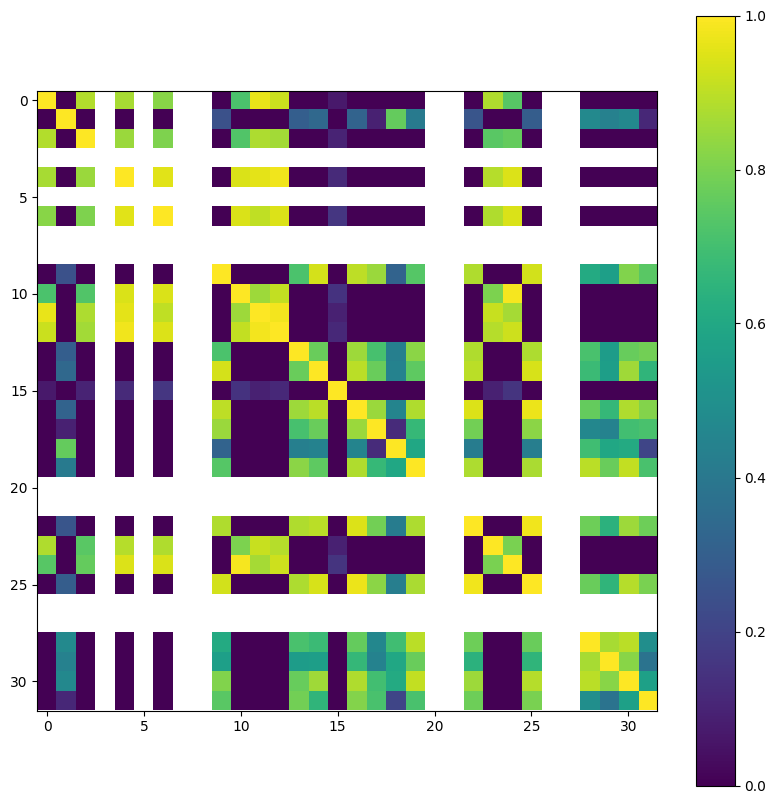

```python
encoder = Model(model.input, model.layers[-2].output)

train_encodings = encoder.predict(train_X)

correlations = [[np.corrcoef(train_encodings[:,i], train_encodings[:,j])[0,1] \
                 for i in range(32)] for j in range(32)]

plt.figure(figsize=(10, 10))
heatmap = plt.imshow(correlations, clim=(0, 1))
plt.colorbar(heatmap)
plt.show()
```

## 23. Reproduzierbarkeitscheck: dieselbe Erklärung erneut

↑ Inhaltsverzeichnis

### Was passiert hier?

Diese Zelle baut die 7-schichtige Strategie erneut auf (identisch zu Abschnitt 20), erzeugt einen neuen Erklärer für dieselbe Ausgabeschicht, erklärt dasselbe Volumen und plottet dieselbe $8\times8$-Abbildung. Inhaltlich ist es eine **Wiederholung** von Abschnitt 20 — die erzeugte Grafik ist byteweise identisch mit der dortigen.

### Warum ist das trotzdem nützlich?

Weil die Gleichheit selbst eine Information ist, und zwar in drei Punkten:

1. **LRP ist deterministisch.** Anders als etwa Occlusion- oder Sampling-Verfahren (LIME, SHAP mit Stichproben) enthält LRP keine Zufallskomponente. Zweimal derselbe Aufruf ergibt exakt dasselbe Ergebnis. Bei stochastischen Erklärungsverfahren wäre hier ein Unterschied zu sehen — und genau das wäre ein wichtiger Warnhinweis, denn eine Erklärung, die bei jedem Aufruf anders aussieht, ist schwer zu verantworten.
2. **Das Erzeugen eines Erklärers hat keine Nebenwirkungen** auf das erklärte Modell. `LayerwiseRelevancePropagator` baut intern ein *neues* Modell (inklusive `remove_activation` und `fuse_batchnorm`), lässt das Original aber unangetastet. Sonst würde die zweite Erklärung von der ersten abweichen. Das ist bei Bibliotheken, die Modelle umbauen, keine Selbstverständlichkeit und der Test daher berechtigt.
3. **Dropout ist im Inferenzmodus tatsächlich aus.** Wäre es aktiv, würden die beiden Durchläufe unterschiedliche Karten liefern.

### Interpretation

```
1/1 ━━━━━━━━━━━━━━━━━━━━ 0s 2s/step
```

```
1/1 ━━━━━━━━━━━━━━━━━━━━ 2s 2s/step
```

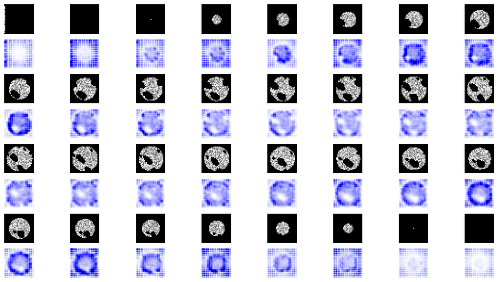

```python
strategy = LRPStrategy(
    layers=[
        {'flat': True},
        {'alpha': 2, 'beta': 1},
        {'alpha': 2, 'beta': 1},
        {'alpha': 2, 'beta': 1},
        {'alpha': 2, 'beta': 1},
        {'epsilon': 0.25},
        {'epsilon': 0.25}
    ]
)

explainer = LayerwiseRelevancePropagator(model, layer=len(model.layers) - 1, idx=0, strategy=strategy)
explanations = explainer.predict(np.expand_dims(brain, 0))[0]
explanations = explanations / np.amax(np.abs(explanations))

fig, ax = plt.subplots(8, 8, figsize=(15, 8))

for i in range(0, 8, 2):
    for j in range(8):
        idx = ((i // 2) * 8)+ j

        ax[i][j].imshow(brain[idx], cmap='Greys_r')
        ax[i][j].axis('off')
        ax[i+1][j].imshow(explanations[idx], cmap='seismic', clim=(-1, 1))
        ax[i+1][j].axis('off')

plt.show()
```

### 23b. RestructuredLRP für Modell 2 (deaktiviert)

↑ Inhaltsverzeichnis

Wie in Abschnitt 15, nur für Modell 2: der Code ist als String deaktiviert und wird nicht ausgeführt. Geplant war die kontrastive Erklärung relativ zum Prototyp `mean_encoding` der Gruppe mit Label 5, dargestellt als vierzeilige Abbildung (Volumen / Standard-LRP / RestructuredLRP / Differenz).

Bei Modell 2 wäre der Vergleich besonders interessant, weil dieses Modell durch den auf 5 fixierten Bias schon *implizit* kontrastiv rechnet ($f(X) = 5 + w^\top h(X)$). Die Frage wäre also: Bringt eine explizit kontrastive Erklärung noch zusätzliche Information, wenn das Modell bereits gegen den Mittelwert arbeitet? Die vierte Zeile der Abbildung (die Differenz) hätte genau darauf geantwortet — wäre sie überall nahe weiß, wären beide Ansätze äquivalent.

```python
"""
from explainability import RestructuredLRP

restructured_lrp = RestructuredLRP(
    model, layer=output_layer, idx=0, bottleneck=bottleneck_layer, strategy=strategy
)
restructured_explanations = restructured_lrp.predict([np.expand_dims(brain, 0),
                                                      np.expand_dims(mean_encoding, 0)])[0]
restructured_explanations = restructured_explanations / np.amax(np.abs(restructured_explanations))

fig, ax = plt.subplots(4, 8, figsize=(15, 4))


for i in range(8):
    ax[0][i].imshow(brain[12+i], cmap='Greys_r')
    ax[0][i].axis('off')
    ax[1][i].imshow(explanations[12+i], cmap='seismic', clim=(-1, 1))
    ax[1][i].axis('off')
    ax[2][i].imshow(restructured_explanations[12+i], cmap='seismic', clim=(-1, 1))
    ax[2][i].axis('off')
    ax[3][i].imshow(restructured_explanations[12+i] - explanations[12+i], cmap='seismic', clim=(-1, 1))
    ax[3][i].axis('off')

plt.show()
"""
```

```
"\nfrom explainability import RestructuredLRP\n    \nrestructured_lrp = RestructuredLRP(\n    model, layer=output_layer, idx=0, bottleneck=bottleneck_layer, strategy=strategy\n)\nrestructured_explanations = restructured_lrp.predict([np.expand_dims(brain, 0), \n                                       …
```

## 24. Referenz-Encodings für Modell 2

↑ Inhaltsverzeichnis

### Was passiert hier?

Exakt dieselbe Rechnung wie in Abschnitt 14, jetzt aber mit den Gewichten von Modell 2: Encoder bis zur `Dense(32)`-Schicht bauen, alle Testvolumen kodieren, die Gruppe mit Label $y = 5$ auswählen und deren Mittelwert und Streuung im Merkmalsraum bestimmen.

$$\bar{z} = \frac{1}{|G|}\sum_{n \in G} z^{(n)}, \qquad \sigma_k = \operatorname{std}_{n \in G}\big(z^{(n)}_k\big)$$

Diese Wiederholung ist nötig, weil `model` in Abschnitt 18 überschrieben wurde: `mean_encoding` und `encoding_stddev` aus Abschnitt 14 gehören noch zu Modell 1 und wären für Modell 2 wertlos. Ein gutes Beispiel dafür, wie schnell in Notebooks Variablen und Modelle auseinanderlaufen — und warum man solche abgeleiteten Größen immer direkt nach dem zugehörigen Modell neu berechnen sollte.

Hier wird `bottleneck_layer` verwendet, also die **lineare** `Dense(32)`-Ausgabe (und nicht wie in Abschnitt 22 die ReLU-Ausgabe). Für RestructuredLRP ist das Voraussetzung: die Bibliothek verlangt eine lineare Bottleneck-Schicht, damit die Differenz $z - \bar{z}$ mathematisch sauber weiterpropagiert werden kann.

### Ausgabe

Nur die Fortschrittsbalken von `encoder.predict`. Die Zelle bereitet die Eingaben für die letzte (deaktivierte) Zelle vor.

```python
encoder = Model(model.input, model.layers[bottleneck_layer].output)
encodings = encoder.predict(test_X)
group_idx = np.where(test_y == 5)[0]
group_encodings = encodings[group_idx]
mean_encoding = np.mean(group_encodings, axis=0)
encoding_stddev = np.std(group_encodings, axis=0)
```

```
1/7 ━━━━━━━━━━━━━━━━━━━━ 5s 836ms/step
```

```
7/7 ━━━━━━━━━━━━━━━━━━━━ 0s 138ms/step
```

```
7/7 ━━━━━━━━━━━━━━━━━━━━ 2s 141ms/step
```

### 24b. RestructuredLRP mit Schwellenwert für Modell 2 (deaktiviert)

↑ Inhaltsverzeichnis

Die letzte inhaltliche Zelle, ebenfalls deaktiviert. Sie ist die Schwellenwert-Variante für Modell 2. Ein Detail lohnt die Aufmerksamkeit: übergeben wird `encoding_stddev * 8`, also eine **achtfache** Streuung als Schwelle. In Abschnitt 15b war es die einfache Streuung.

Der Faktor ist ein Regler für die Sparsamkeit der Erklärung:

$$\delta_k \ne 0 \iff |z_k - \bar{z}_k| > \tau\,\sigma_k$$

- $\tau$ klein → viele Merkmale überschreiten die Schwelle → dichte Heatmap.
- $\tau$ groß → nur extreme Abweichungen bleiben → sehr sparsame Heatmap.

$\tau = 8$ ist ein sehr strenger Wert; unter einer Normalverteilungsannahme wäre eine Abweichung von acht Standardabweichungen praktisch unmöglich. Dass er hier nötig scheint, deutet darauf hin, dass die Merkmalsstreuung innerhalb der Referenzgruppe klein ist im Verhältnis zu den Unterschieden zwischen Gruppen — oder einfach, dass der Wert experimentell nachjustiert wurde. In der Praxis ist genau das der Punkt, an dem eine Erklärungsmethode selbst Hyperparameter bekommt, und man sollte ehrlich benennen, dass die "Sparsamkeit" einer Heatmap damit zu einer **Entscheidung des Anwenders** wird und nicht mehr allein eine Eigenschaft des Modells ist.

```python
"""
from explainability import RestructuredLRP

restructured_lrp = RestructuredLRP(
    model, layer=output_layer, idx=0, bottleneck=bottleneck_layer,
    strategy=strategy, threshold=True
)
restructured_explanations = restructured_lrp.predict([np.expand_dims(brain, 0),
                                                      np.expand_dims(mean_encoding, 0),
                                                      np.expand_dims(encoding_stddev * 8, 0)])[0]
restructured_explanations = restructured_explanations / np.amax(np.abs(restructured_explanations))

fig, ax = plt.subplots(4, 8, figsize=(15, 4))


for i in range(8):
    ax[0][i].imshow(brain[12+i], cmap='Greys_r')
    ax[0][i].axis('off')
    ax[1][i].imshow(explanations[12+i], cmap='seismic', clim=(-1, 1))
    ax[1][i].axis('off')
    ax[2][i].imshow(restructured_explanations[12+i], cmap='seismic', clim=(-1, 1))
    ax[2][i].axis('off')
    ax[3][i].imshow(restructured_explanations[12+i] - explanations[12+i], cmap='seismic', clim=(-1, 1))
    ax[3][i].axis('off')

plt.show()
"""
```

```
"\nfrom explainability import RestructuredLRP\n    \nrestructured_lrp = RestructuredLRP(\n    model, layer=output_layer, idx=0, bottleneck=bottleneck_layer,\n    strategy=strategy, threshold=True\n)\nrestructured_explanations = restructured_lrp.predict([np.expand_dims(brain, 0), \n                  …
```

## 25. Fazit und Ausblick

↑ Inhaltsverzeichnis

### Was dieses Notebook demonstriert

Der eigentliche Wert liegt nicht in einem guten Modell, sondern in einem **Prüfverfahren für Erklärungen**. Fünf Bausteine, die man auf jedes eigene Projekt übertragen kann:

| # | Baustein | Abschnitt | Leitfrage |
| --- | --- | --- | --- |
| 1 | Synthetische Daten mit bekannter Ground Truth | 1 | Kenne ich die richtige Erklärung? |
| 2 | Modellgüte *vor* der Erklärung prüfen | 8, 9 | Ist das Modell überhaupt erklärungswürdig? |
| 3 | Heatmaps mit Vorzeichen lesen | 10, 13 | Wo ist Evidenz *für* und *gegen* die Vorhersage? |
| 4 | Kausale Eingriffe | 11, 12 | Reagiert das Modell auf das Richtige und *nicht* auf das Falsche? |
| 5 | Repräsentation analysieren | 14, 16, 17, 21, 22 | Ist die interne Kodierung überhaupt interpretierbar? |

### Die wichtigsten Einsichten im Rückblick

**Zur Erklärbarkeit:**

- Eine Heatmap zeigt immer *Modell × Erklärungsregel*, nie das Modell allein. Der deutlichste Beleg: In Abschnitt 13 tragen komplett leere Bildschichten Relevanz — ein Effekt der `flat`-Regel, nicht der Daten.
- Architektur bestimmt Erklärbarkeit mit. Global Average Pooling erzwingt Translationsinvarianz (gut für die Aufgabe), zerstört aber Ortsinformation (schlecht für Heatmaps). Modell 2 zeigt in Abschnitt 20 sichtbar besser lokalisierte Relevanz an Kugelkontur und Tunnelwänden.
- Vorzeichen sind Information: Bei Modell 1 war Gewebe blau (senkt die Vorhersage) und Leerraum rot (erhöht sie) — das ist die inhaltlich korrekte Logik. Bei Modell 2 verschiebt der fixierte Bias die Referenz und damit das Gesamtvorzeichen, ohne dass sich der Mechanismus geändert hätte.
- Kausale Tests sind stärker als Heatmaps. Abschnitt 12 hat gezeigt, dass breite Bohrungen etwa zehnmal so große Vorhersagesprünge erzeugen wie schmale — der überzeugendste Beleg dieses Notebooks dafür, dass das Modell die *richtige* Größe misst.
- Erklärungen auf Neuronenebene brauchen eine entwirrte Repräsentation. Solange 32 Bottleneck-Neuronen fast dieselbe Karte liefern (Abschnitte 16 und 21), ist die Aussage "Neuron $k$ kodiert $X$" nicht identifizierbar.

**Zum Deep Learning allgemein:**

- Loss-Werte brauchen eine Baseline. $\operatorname{Var}(y) = 8.25$ ist hier die Messlatte; Modell 1 lag nach zwei Epochen mit 17.5 darüber, Modell 2 mit 3.0 darunter.
- Eine gute Initialisierung ersetzt viel Training. Der auf 5 fixierte Ausgabe-Bias von Modell 2 senkt den Startverlust um Faktor 5.
- Warnungen sind Befunde. Das `RuntimeWarning` in Abschnitt 22 hat tote ReLU-Neuronen aufgedeckt.
- Notebook-Zustand ist gefährlich. `model` wird überschrieben, `y` kann durch eine Plot-Zelle zerstört werden — die `assert`-Anweisungen im Notebook sind kein Zierrat.

### Wie man von hier weiterarbeitet

In der Reihenfolge des Nutzens:

1. **`epochs=500` setzen** (in den Abschnitten 8 und 19). Das ist der einzige Schritt, der aus einer Methodendemonstration eine inhaltliche Aussage macht. Alle Interpretationen oben stehen unter dem Vorbehalt zweier Trainingsepochen.
2. **Das Streudiagramm erneut prüfen** (Abschnitt 9). Erst wenn die Punkte ungefähr auf der Diagonale liegen, sind die Heatmaps inhaltlich belastbar.
3. **Die kausalen Tests wiederholen** (Abschnitte 11 und 12). Wird die Kurve über die Tunnelanzahl endlich flach (Invarianz) und die Treppe über die Breiten endlich sauber?
4. **`NUM_TUNNELS` in den Trainingsdaten variieren.** Solange immer genau 6 Tunnel gebohrt werden, *kann* das Modell nicht lernen, die Anzahl zu ignorieren.
5. **Die `flat`-Regel durch die $z^\mathcal{B}$-Regel ersetzen**, um die Relevanz-Leckage in leere Bildbereiche zu beseitigen.
6. **Redundanz quantifizieren** statt nur zu betrachten: PCA oder effektive Dimension des Bottlenecks, und die Korrelationsmatrix mit $|r|$ bzw. `clim=(-1,1)` plotten, damit Antikorrelationen sichtbar werden.
7. **`RestructuredLRP` wieder zum Laufen bringen** — die vier deaktivierten Zellen enthalten den methodisch interessantesten Teil des Repos.

### Der Bogen zurück zum Anfang

Ziel war nie die Tunnelbreite. Ziel war die Frage, ob man einer Heatmap glauben darf. Auf diesem synthetischen Datensatz kann man das prüfen, weil wir die Antwort kennen. Erst wenn eine Erklärungsmethode hier alle fünf Prüfungen besteht, hat man ein Recht darauf, sie auf echte MRT-Daten anzuwenden — wo niemand die richtige Antwort kennt und eine plausibel aussehende, aber falsche Heatmap echten Schaden anrichten kann.